# Evidence for conserved long UTR lengths in Casein Kinase I transcripts; code used in Kelliher et al 2020 Supplementary Figure 7

Tina Kelliher

12/2/2020

```r
knitr::opts_chunk$set(echo = TRUE, warning = FALSE, message = FALSE)

## install.packages("stringr")
## install stringR into your session if you have not previously done so

library(stringr)

library(googledrive)
```

## Setup: download genome annotation files locally

To run this R script locally, you will need access to the *Neurospora crassa*, *Drosophila melanogaster*, *Mus musculus*, and *Homo sapiens* genome annotation files.

Genome annotations can be found in my Dartmouth Google Drive, publically shared sub-directory: “Kelliher_et_al_2020”.

To download the files, you can either:

1. run the following chunk of R code, OR
2. download manually from: “https://drive.google.com/drive/folders/1UstcHGa-OtXbxirDOI7IhcM4VZXz9ENH?usp=sharing”. Create a folder called “input_data” in the same directory as this markdown file “Supp_Fig_7.Rmd” on your file system. Move the 4 downloaded genome annotation files into this folder called “input_data”.

```r
## install.packages("googledrive")
## install GoogleDrive into your session if you have not previously done so

data_url <- "https://drive.google.com/drive/folders/1UstcHGa-OtXbxirDOI7IhcM4VZXz9ENH?usp=sharing"

folder <- drive_get(as_id(data_url))
## if running googledrive synatax for the first time, you will need to grant the Tidyverse API Packages access to your Google Account
## if you select "no access", this step will generate: Permission Error 403
## to check directory contents, use: drive_ls(data_url)

drive_download(as_id("1gfco5VudAazoRoKFEsh8-P2aLrejzGG5"), path="./input_data/FungiDB-45_NcrassaOR74A_rmSpaces.gff")

drive_download(as_id("1SxlUS1xrXH5GaH8QEsZKLPUdL9SH-Rfh"), path="./input_data/D_melanogaster_Ensembl_BDGP6_genes.gtf")

drive_download(as_id("1p7pbYWpECDK-nNeWDXyULfBk1iIfWdQy"), path="./input_data/M_musculus_Ensembl_GRCm38_genes.gtf")

drive_download(as_id("1lPvAXHBpFZV79rqUAcbB7EfFelzizxlX"), path="./input_data/H_sapiens_Ensembl_GRCh37_genes.gtf")
```

## Figure A) *Neurospora crassa*

Gene annotation files downloaded from FungiDB version 45: https://fungidb.org/common/downloads/release-45/NcrassaOR74A/

Accessed: 10/25/2019 by CMK

Modifications to raw file: using TextWrangler, spaces were replaced with underscores using Find and Replace (i.e. " " to “_“; 38,187 replacements)

```r
gff <- as.data.frame(read.table("./input_data/FungiDB-45_NcrassaOR74A_rmSpaces.gff", stringsAsFactors=FALSE))
```

```r
gff_UTRs <- gff[which(gff$V3=="three_prime_UTR"),]
gff_sub <- cbind(gff_UTRs[,4], gff_UTRs[,5], gff_UTRs[,9])
gff_sub <- data.frame(gff_sub, stringsAsFactors=FALSE)
names(gff_sub) <- c("start", "end", "gene_info")
labels <- str_extract(gff_sub$gene_info, paste("Parent=NCU", "[0-9]{5}", sep=""))
labels_sub <- sub("Parent=", "", labels)
gff_sub_v2 <- cbind(labels_sub, gff_sub[1:2])
gff_sub_v2 <- data.frame(gff_sub_v2, stringsAsFactors=FALSE)
names(gff_sub_v2) <- c("gene_UTR", "start", "end")
UTR_length <- as.numeric(gff_sub_v2$end) - as.numeric(gff_sub_v2$start)
gff_sub_v3 <- cbind(gff_sub_v2, UTR_length)
gff_sub_v3 <- data.frame(gff_sub_v3, stringsAsFactors=FALSE)
names(gff_sub_v3) <- c("gene_UTR", "start", "end", "length_UTR")
gff_sub_v3 <- gff_sub_v3[order(as.numeric(gff_sub_v3$length_UTR), decreasing=TRUE),]
gff_sub_v4 <- gff_sub_v3[!duplicated(gff_sub_v3$gene_UTR),]
## keep only the longest 3' UTR recorded for each unique gene ID
UTR_length_logs <- log(as.numeric(gff_sub_v4$length_UTR), 2)
gff_sub_v5 <- cbind(gff_sub_v4, UTR_length_logs)
gff_sub_v5 <- data.frame(gff_sub_v5, stringsAsFactors=FALSE)
names(gff_sub_v5) <- c("gene_UTR", "start", "end", "length_UTR", "log2_length_UTR")
## write.table(gff_sub_v5, "./N_crassa_FungiDB45_7793_longest_UTRs.txt", quote=F, row.names=F, sep="\t")
## un-comment the above line to save the UTR annotation output
rm(gff)
rm(gff_UTRs)
rm(gff_sub)
rm(gff_sub_v2)
rm(gff_sub_v3)
rm(gff_sub_v4)
## clear the worspace memory for the next organism

ck1 <- "NCU00685"
## ck-1a: https://fungidb.org/fungidb/app/record/gene/NCU00685
ck1_idx <- as.numeric(which(gff_sub_v5$gene_UTR==ck1))
perc <- ck1_idx / nrow(gff_sub_v5) * 100
print(paste("N. crassa CK1 longest 3' UTR is in the top: ", round(perc, 3), "%", sep=""))
```

```
## [1] "N. crassa CK1 longest 3' UTR is in the top: 1.116%"
```

```r
print(paste("Number of annotated N. crassa UTRs: ", round(nrow(gff_sub_v5), 3), sep=""))
```

```
## [1] "Number of annotated N. crassa UTRs: 7793"
```

```r
print(paste("Length of CK1 UTR: ", round(gff_sub_v5[ck1_idx,4], 3), " bps", sep=""))
```

```
## [1] "Length of CK1 UTR: 1739 bps"
```

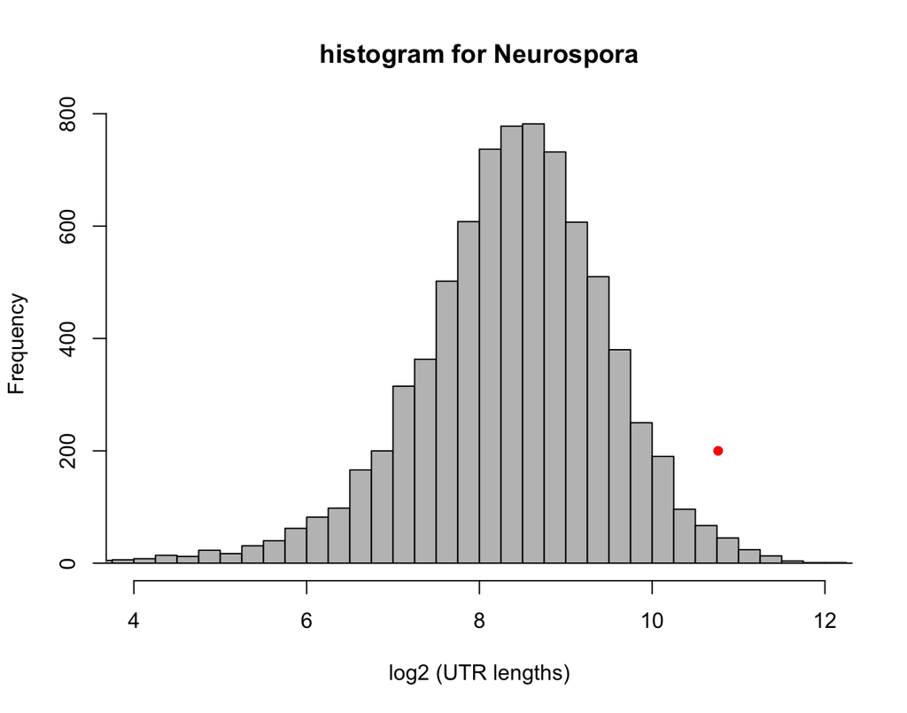

```r
ck1_UTR <- as.numeric(gff_sub_v5[ck1_idx,5])

bins <- seq(0, 14, by=0.25)
hist(gff_sub_v5$log2_length_UTR, breaks=bins, ylab="Frequency", xlab="log2 (UTR lengths)", main="histogram for Neurospora", col="gray75", xlim=c(4,12))
points(x=ck1_UTR, y=200, pch=16, col="red") ## ck-1a
```

```r
## Exported figure as SVG (700w x 550h) for Inkscape
```

## Figure B) *Drosophila melanogaster*

Gene annotation files downloaded from Illumina iGenomes: https://support.illumina.com/sequencing/sequencing_software/igenome.html

Accessed: 8/5/2020 by CMK

```r
gff_fly <- as.data.frame(read.table("./input_data/D_melanogaster_Ensembl_BDGP6_genes.gtf", sep="\t", stringsAsFactors=FALSE))
```

```r
gff_fly_UTRs <- gff_fly[which(gff_fly$V3=="UTR"),]
gff_fly_sub <- cbind(gff_fly_UTRs[,4], gff_fly_UTRs[,5], gff_fly_UTRs[,9])
gff_fly_sub <- data.frame(gff_fly_sub, stringsAsFactors=FALSE)
names(gff_fly_sub) <- c("start", "end", "gene_info")
labels_fly <- str_extract(gff_fly_sub$gene_info, paste("gene_id FBgn", "[0-9]{7}", sep=""))
labels_fly_sub <- sub("gene_id ", "", labels_fly)
gff_fly_sub_v2 <- cbind(labels_fly_sub, gff_fly_sub[1:2])
gff_fly_sub_v2 <- data.frame(gff_fly_sub_v2, stringsAsFactors=FALSE)
names(gff_fly_sub_v2) <- c("gene_UTR", "start", "end")
UTR_length_fly <- as.numeric(gff_fly_sub_v2$end) - as.numeric(gff_fly_sub_v2$start)
gff_fly_sub_v3 <- cbind(gff_fly_sub_v2, UTR_length_fly)
gff_fly_sub_v3 <- data.frame(gff_fly_sub_v3, stringsAsFactors=FALSE)
names(gff_fly_sub_v3) <- c("gene_UTR", "start", "end", "length_UTR")
gff_fly_sub_v3 <- gff_fly_sub_v3[order(as.numeric(gff_fly_sub_v3$length_UTR), decreasing=TRUE),]
gff_fly_sub_v4 <- gff_fly_sub_v3[!duplicated(gff_fly_sub_v3$gene_UTR),]
## keep only the longest UTR recorded for each unique gene ID
UTR_length_logs <- log(as.numeric(gff_fly_sub_v4$length_UTR), 2)
gff_fly_sub_v5 <- cbind(gff_fly_sub_v4, UTR_length_logs)
gff_fly_sub_v5 <- data.frame(gff_fly_sub_v5, stringsAsFactors=FALSE)
names(gff_fly_sub_v5) <- c("gene_UTR", "start", "end", "length_UTR", "log2_length_UTR")
## write.table(gff_fly_sub_v5, "./D_melanogaster_Ensembl_BDGP6_13552_longest_UTRs.txt", quote=F, row.names=F, sep="\t")
## un-comment the above line to save the UTR annotation output
rm(gff_fly)
rm(gff_fly_UTRs)
rm(gff_fly_sub)
rm(gff_fly_sub_v2)
rm(gff_fly_sub_v3)
rm(gff_fly_sub_v4)
## clear the worspace memory for the next organism

ck1 <- "FBgn0002413"
## DBT: https://flybase.org/reports/FBgn0002413
ck1_idx <- as.numeric(which(gff_fly_sub_v5$gene_UTR==ck1))
perc <- ck1_idx / nrow(gff_fly_sub_v5) * 100
print(paste("Fly CK1 longest UTR is in the top: ", round(perc, 3), "%", sep=""))
```

```
## [1] "Fly CK1 longest UTR is in the top: 3.372%"
```

```r
print(paste("Number of annotated fly UTRs: ", round(nrow(gff_fly_sub_v5), 3), sep=""))
```

```
## [1] "Number of annotated fly UTRs: 13552"
```

```r
print(paste("Length of CK1 UTR: ", round(gff_fly_sub_v5[ck1_idx,4], 3), " bps", sep=""))
```

```
## [1] "Length of CK1 UTR: 2443 bps"
```

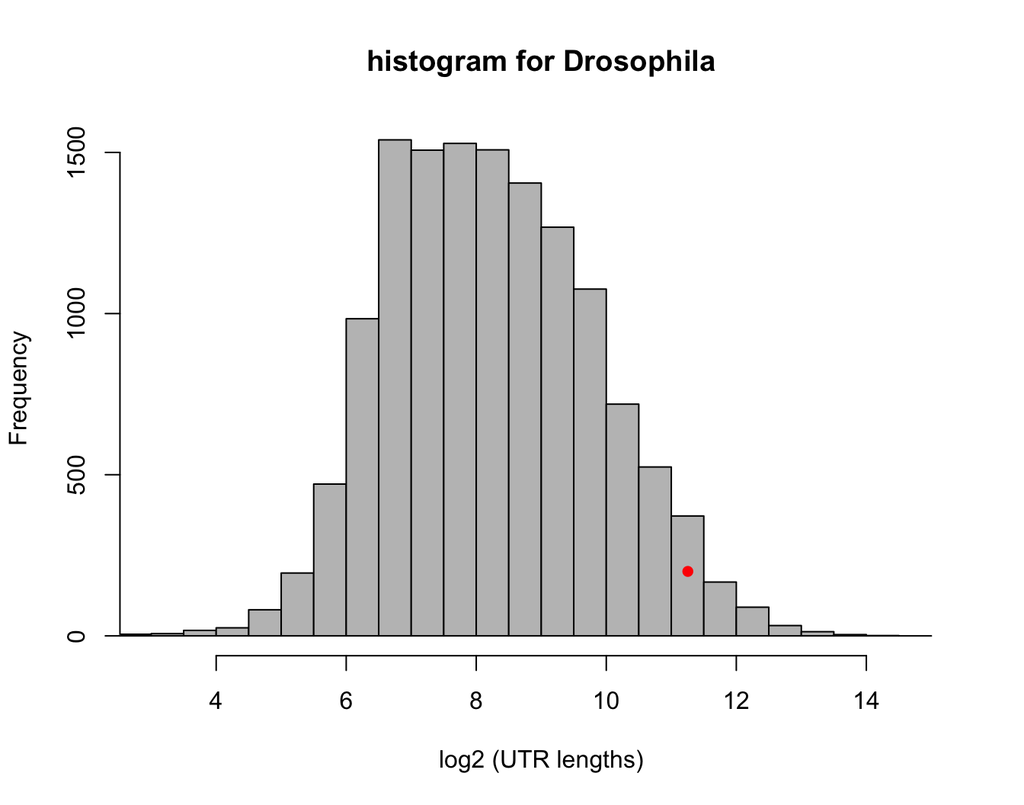

```r
ck1_UTR <- as.numeric(gff_fly_sub_v5[ck1_idx,5])

bins <- seq(0, 15, by=0.5)
hist(gff_fly_sub_v5$log2_length_UTR, breaks=bins, ylab="Frequency", xlab="log2 (UTR lengths)", main="histogram for Drosophila", col="gray75", xlim=c(3,15))
points(x=ck1_UTR, y=200, pch=16, col="red") ## DBT
```

```r
## Exported figure as SVG (700w x 550h) for Inkscape
```

## Figure C) *Mus musculus*

Gene annotation files downloaded from Illumina iGenomes: https://support.illumina.com/sequencing/sequencing_software/igenome.html

Accessed: 8/5/2020 by CMK

```r
gff_m <- as.data.frame(read.table("./input_data/M_musculus_Ensembl_GRCm38_genes.gtf", sep="\t", stringsAsFactors=FALSE))
```

```r
gff_m_UTRs <- gff_m[which(gff_m$V3=="UTR"),]
gff_m_sub <- cbind(gff_m_UTRs[,4], gff_m_UTRs[,5], gff_m_UTRs[,9])
gff_m_sub <- data.frame(gff_m_sub, stringsAsFactors=FALSE)
names(gff_m_sub) <- c("start", "end", "gene_info")
labels_m <- str_extract(gff_m_sub$gene_info, paste("gene_id ENSMUSG", "[0-9]{11}", sep=""))
labels_m_sub <- sub("gene_id ", "", labels_m)
gff_m_sub_v2 <- cbind(labels_m_sub, gff_m_sub[1:2])
gff_m_sub_v2 <- data.frame(gff_m_sub_v2, stringsAsFactors=FALSE)
names(gff_m_sub_v2) <- c("gene_UTR", "start", "end")
UTR_length_m <- as.numeric(gff_m_sub_v2$end) - as.numeric(gff_m_sub_v2$start)
gff_m_sub_v3 <- cbind(gff_m_sub_v2, UTR_length_m)
gff_m_sub_v3 <- data.frame(gff_m_sub_v3, stringsAsFactors=FALSE)
names(gff_m_sub_v3) <- c("gene_UTR", "start", "end", "length_UTR")
gff_m_sub_v3 <- gff_m_sub_v3[order(as.numeric(gff_m_sub_v3$length_UTR), decreasing=TRUE),]
gff_m_sub_v4 <- gff_m_sub_v3[!duplicated(gff_m_sub_v3$gene_UTR),]
## keep only the longest UTR recorded for each unique gene ID
UTR_length_logs_m <- log(as.numeric(gff_m_sub_v4$length_UTR), 2)
gff_m_sub_v5 <- cbind(gff_m_sub_v4, UTR_length_logs_m)
gff_m_sub_v5 <- data.frame(gff_m_sub_v5, stringsAsFactors=FALSE)
names(gff_m_sub_v5) <- c("gene_UTR", "start", "end", "length_UTR", "log2_length_UTR")
## write.table(gff_m_sub_v5, "./M_musculus_Ensembl_GRCm38_20477_longest_UTRs.txt", quote=F, row.names=F, sep="\t")
## un-comment the above line to save the UTR annotation output
rm(gff_m)
rm(gff_m_UTRs)
rm(gff_m_sub)
rm(gff_m_sub_v2)
rm(gff_m_sub_v3)
rm(gff_m_sub_v4)
## clear the worspace memory for the next organism

ck1d <- "ENSMUSG00000025162"
## Csnk1d: http://www.informatics.jax.org/marker/MGI:1355272
ck1e <- "ENSMUSG00000022433"
## Csnk1e: http://www.informatics.jax.org/marker/MGI:1351660

ck1d_idx <- as.numeric(which(gff_m_sub_v5$gene_UTR==ck1d))
perc <- ck1d_idx / nrow(gff_m_sub_v5) * 100
print(paste("Mouse CK1delta longest UTR is in the top: ", round(perc, 3), "%", sep=""))
```

```
## [1] "Mouse CK1delta longest UTR is in the top: 19.29%"
```

```r
ck1d_UTR <- as.numeric(gff_m_sub_v5[ck1d_idx,5])

ck1e_idx <- as.numeric(which(gff_m_sub_v5$gene_UTR==ck1e))
perce <- ck1e_idx / nrow(gff_m_sub_v5) * 100
print(paste("Mouse CK1epsilon longest UTR is in the top: ", round(perce, 3), "%", sep=""))
```

```
## [1] "Mouse CK1epsilon longest UTR is in the top: 32.436%"
```

```r
ck1e_UTR <- as.numeric(gff_m_sub_v5[ck1e_idx,5])

print(paste("Number of annotated mouse UTRs: ", round(nrow(gff_m_sub_v5), 3), sep=""))
```

```
## [1] "Number of annotated mouse UTRs: 20477"
```

```r
print(paste("Length of CK1d UTR: ", round(gff_m_sub_v5[ck1d_idx,4], 3), " bps", sep=""))
```

```
## [1] "Length of CK1d UTR: 2157 bps"
```

```r
print(paste("Length of CK1e UTR: ", round(gff_m_sub_v5[ck1e_idx,4], 3), " bps", sep=""))
```

```
## [1] "Length of CK1e UTR: 1456 bps"
```

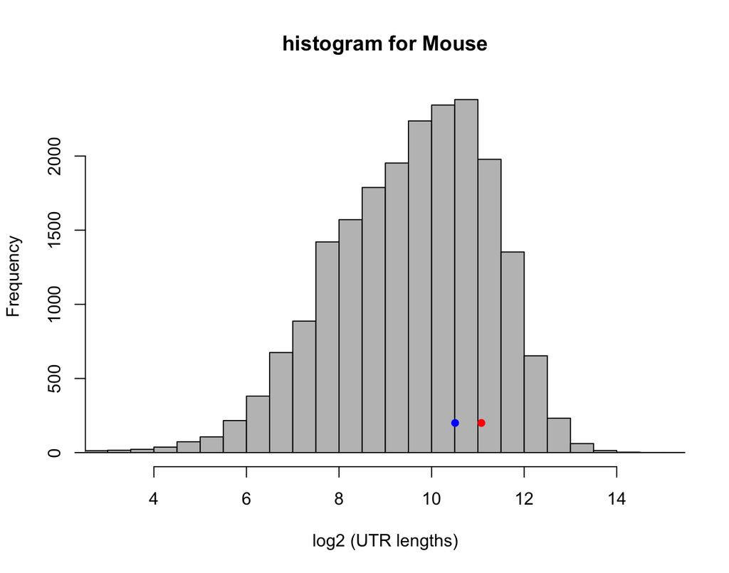

```r
bins <- seq(0, 16, by=0.5)
hist(gff_m_sub_v5$log2_length_UTR, breaks=bins, ylab="Frequency", xlab="log2 (UTR lengths)", main="histogram for Mouse", col="gray75", xlim=c(3,15))
points(x=ck1d_UTR, y=200, pch=16, col="red") ## CK1delta
points(x=ck1e_UTR, y=200, pch=16, col="blue") ## CK1epsilon
```

```r
## Exported figure as SVG (700w x 550h) for Inkscape
```

## Figure D) *Homo sapiens*

Gene annotation files downloaded from Illumina iGenomes: https://support.illumina.com/sequencing/sequencing_software/igenome.html

Accessed: 8/5/2020 by CMK

```r
gff_h <- as.data.frame(read.table("./input_data/H_sapiens_Ensembl_GRCh37_genes.gtf", sep="\t", stringsAsFactors=FALSE))
```

```r
gff_h_UTRs <- gff_h[which(gff_h$V3=="UTR"),]
gff_h_sub <- cbind(gff_h_UTRs[,4], gff_h_UTRs[,5], gff_h_UTRs[,9])
gff_h_sub <- data.frame(gff_h_sub, stringsAsFactors=FALSE)
names(gff_h_sub) <- c("start", "end", "gene_info")
labels_h <- str_extract(gff_h_sub$gene_info, paste("gene_id ENSG", "[0-9]{11}", sep=""))
labels_h_sub <- sub("gene_id ", "", labels_h)
gff_h_sub_v2 <- cbind(labels_h_sub, gff_h_sub[1:2])
gff_h_sub_v2 <- data.frame(gff_h_sub_v2, stringsAsFactors=FALSE)
names(gff_h_sub_v2) <- c("gene_UTR", "start", "end")
UTR_length_h <- as.numeric(gff_h_sub_v2$end) - as.numeric(gff_h_sub_v2$start)
gff_h_sub_v3 <- cbind(gff_h_sub_v2, UTR_length_h)
gff_h_sub_v3 <- data.frame(gff_h_sub_v3, stringsAsFactors=FALSE)
names(gff_h_sub_v3) <- c("gene_UTR", "start", "end", "length_UTR")
gff_h_sub_v3 <- gff_h_sub_v3[order(as.numeric(gff_h_sub_v3$length_UTR), decreasing=TRUE),]
gff_h_sub_v4 <- gff_h_sub_v3[!duplicated(gff_h_sub_v3$gene_UTR),]
## keep only the longest UTR recorded for each unique gene ID
UTR_length_logs_h <- log(as.numeric(gff_h_sub_v4$length_UTR), 2)
gff_h_sub_v5 <- cbind(gff_h_sub_v4, UTR_length_logs_h)
gff_h_sub_v5 <- data.frame(gff_h_sub_v5, stringsAsFactors=FALSE)
names(gff_h_sub_v5) <- c("gene_UTR", "start", "end", "length_UTR", "log2_length_UTR")
## write.table(gff_h_sub_v5, "./H_sapiens_Ensembl_GRCh37_22401_longest_UTRs.txt", quote=F, row.names=F, sep="\t")
## un-comment the above line to save the UTR annotation output
rm(gff_h)
rm(gff_h_UTRs)
rm(gff_h_sub)
rm(gff_h_sub_v2)
rm(gff_h_sub_v3)
rm(gff_h_sub_v4)
## clear the worspace memory for the next organism

ck1d <- "ENSG00000141551"
## Csnk1d: https://www.ncbi.nlm.nih.gov/gene/1453
ck1e <- "ENSG00000213923"
## Csnk1e: https://www.ncbi.nlm.nih.gov/gene/1454

ck1d_idx <- as.numeric(which(gff_h_sub_v5$gene_UTR==ck1d))
perc <- ck1d_idx / nrow(gff_h_sub_v5) * 100
print(paste("Human CK1delta longest UTR is in the top: ", round(perc, 3), "%", sep=""))
```

```
## [1] "Human CK1delta longest UTR is in the top: 23.106%"
```

```r
ck1d_UTR <- as.numeric(gff_h_sub_v5[ck1d_idx,5])

ck1e_idx <- as.numeric(which(gff_h_sub_v5$gene_UTR==ck1e))
perce <- ck1e_idx / nrow(gff_h_sub_v5) * 100
print(paste("Human CK1epsilon longest UTR is in the top: ", round(perce, 3), "%", sep=""))
```

```
## [1] "Human CK1epsilon longest UTR is in the top: 40.971%"
```

```r
ck1e_UTR <- as.numeric(gff_h_sub_v5[ck1e_idx,5])

print(paste("Number of annotated human UTRs: ", round(nrow(gff_h_sub_v5), 3), sep=""))
```

```
## [1] "Number of annotated human UTRs: 22401"
```

```r
print(paste("Length of CK1d UTR: ", round(gff_h_sub_v5[ck1d_idx,4], 3), " bps", sep=""))
```

```
## [1] "Length of CK1d UTR: 2113 bps"
```

```r
print(paste("Length of CK1e UTR: ", round(gff_h_sub_v5[ck1e_idx,4], 3), " bps", sep=""))
```

```
## [1] "Length of CK1e UTR: 1247 bps"
```

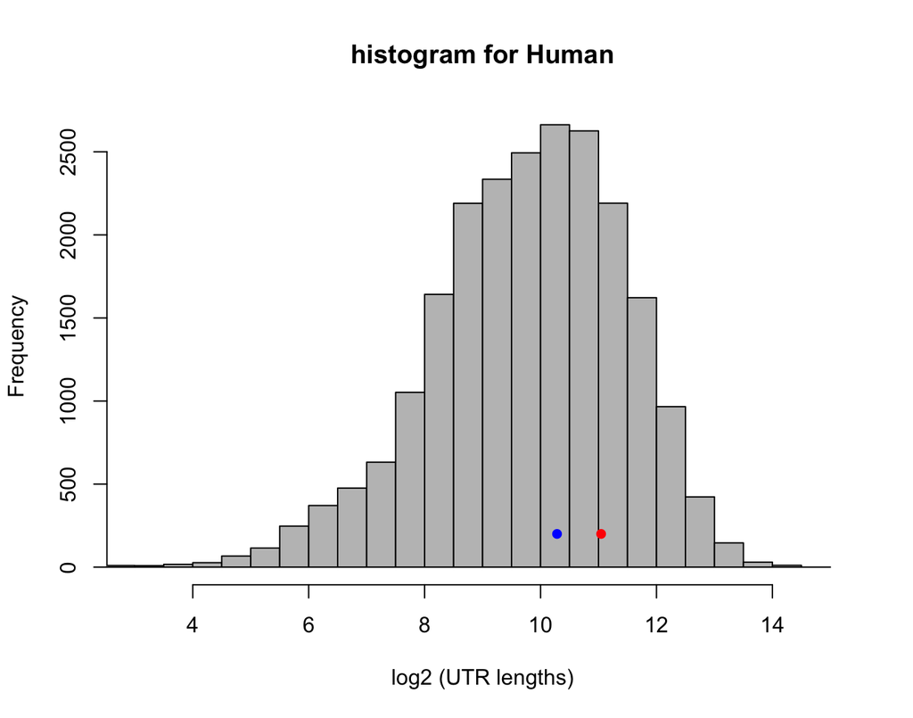

```r
bins <- seq(0, 15, by=0.5)
hist(gff_h_sub_v5$log2_length_UTR, breaks=bins, ylab="Frequency", xlab="log2 (UTR lengths)", main="histogram for Human", col="gray75", xlim=c(3,15))
points(x=ck1d_UTR, y=200, pch=16, col="red") ## CK1delta
points(x=ck1e_UTR, y=200, pch=16, col="blue") ## CK1epsilon
```

```r
## Exported figure as SVG (700w x 550h) for Inkscape
```